# R Programming

Tianhai Zu(zuti@mail.uc.edu)

**Acknowledgment**: the materials below are initilated by Yichen Qin and modified by Tianhai Zu for teaching purpose.

### Introduction to R

Many software choices for linear regression analysis: Excel, Minitab, SPSS, SAS, and R. However, no software is a substitute for creative thinking. For this course, we exclusively use R.

To download and install R, please follow:

- From the R web page (http://www.r-project.org/), click the CRAN link on the left side of the page.
- Select an appropriate mirror for your location (any U.S.A. location is fine)
- Click the appropriate operating system.
- Click base (for the base R software).
- Click the link Download R x.x.x, excute the file and follow the instructions.

Rstudio is a great integrated development environment (IDE) for R.

- It can be downloaded at https://www.rstudio.com/.
- We highly recommend it.

Advantages of R

- R has extensive and powerful graphics abilities
- The R system is developing rapidly. New features and abilities appear every few months. New R packages are submitted to CRAN everyday: https://cran.r-project.org/web/packages/available_packages_by_date.html
- Simple calculations and analyses can be handled straightforwardly. There is a language core that uses standard forms of algebraic notation, allowing the calculations such as 2+3, or 3^11.
- R is an “open source” system. Source-code is available for inspection, or for adaptation to other systems.
- R is free!
- R is a functional language. The structure of an R program is similar to C, JAVA or MatLab.

### R as a calculator

Expressions are typed following the prompt (>) on the screen. The result appears on subsequent lines

```r
2+2  # Addition
```

```
## [1] 4
```

```r
sqrt(10)  # Square root of
```

```
## [1] 3.162278
```

Additionl operators includes the following:

| Operator | Description |
| --- | --- |
| `+` | addition |
| `-` | subtraction |
| `*` | multiplication |
| `/` | division |
| `^` or `**` | exponentiation |

### R objects

All R entities, almost everything, including functions and data structures, exist as objects. R objects can all be operated on as data.

Type in `ls()` to see the names of all objects in your workspace. In the following, we will learn four kinds of objects in R.

- Vectors
- Matrices
- Data Frames
- Lists

### Vectors

Three types of vectos:

```r
x <- c(2,3,5,2,7,1) # Numeric
x
```

```
## [1] 2 3 5 2 7 1
```

```r
y <- c("Canberra","Sydney","Newcastle","Darwin") # Character
y
```

```
## [1] "Canberra"  "Sydney"    "Newcastle" "Darwin"
```

```r
z <- c(TRUE,FALSE,FALSE,FALSE) # Logical
z
```

```
## [1]  TRUE FALSE FALSE FALSE
```

Tips: The `c(...)` an acronym for “concatenate”. The symbol `<-` means “assigning to”.

What if I want to learn more about the R function `c()`? To get on-line, we can use `?`, for example:

```r
?class
??class
```

How to concatenate existing vectors?

```r
x1 <- c(2,3,5,2,7,1)
x2 <- c(0,0,0)
x_join <- c(x1, x2)
x_join
```

```
## [1] 2 3 5 2 7 1 0 0 0
```

Tips: Use `_`, such as `x_join`, in variable names instead of `.`, such as `x.join`, because `.` sometimes means different things in some object-oriented programming languages.

#### Subsetting

To extract elements of vectors, we can:

Specify the indices of the elements that are to be extracted, e.g.

```r
x <- c(3,11,8,15,12) # Assign to x the values 3, 11, 8, 15, 12
x[c(2,4)] # Extract elements (rows) 2 and 4
```

```
## [1] 11 15
```

Or specify a vector of logical values.

```r
x[x>10]
```

```
## [1] 11 15 12
```

#### Other Operations on Vectors

An advantage of R is that it allows flexible operations on vectors. Try the following code and see how it works:

```r
x_join+1
```

```
## [1] 3 4 6 3 8 2 1 1 1
```

```r
x_join*2
```

```
## [1]  4  6 10  4 14  2  0  0  0
```

```r
log(x_join)
```

```
## [1] 0.6931472 1.0986123 1.6094379 0.6931472 1.9459101 0.0000000      -Inf
## [8]      -Inf      -Inf
```

```r
sum(x_join)
```

```
## [1] 20
```

```r
mean(x_join)
```

```
## [1] 2.222222
```

#### Summarize Vectors

Suppose you are given the following vector:

```r
vv <- rnorm(1000)
```

where `rnorm(1000)` means generate 1000 copies of random variables that follow standard normal distribution with mean zero and variance one, i.e., $N(0,1)$.

How to summarize the information of vector?

```r
vv[1:20]    # Get a sense of the data
```

```
##  [1]  0.31305736  0.25876387 -0.90024451  0.08902754 -0.18750180 -0.38349161
##  [7]  2.45937581 -1.29006418  0.05432386  0.27610338  0.84463287 -0.18307603
## [13] -0.62665444 -0.20292712 -0.69857687  1.88796299 -0.84485625 -0.17561151
## [19] -1.20074211  0.24606097
```

```r
class(vv)   # Which class the vector belongs to
```

```
## [1] "numeric"
```

```r
length(vv)  # What is the size of the vector
```

```
## [1] 1000
```

```r
summary(vv) # Numerical summary
```

```
##     Min.  1st Qu.   Median     Mean  3rd Qu.     Max.
## -3.13345 -0.74195 -0.08150 -0.04956  0.62027  3.60127
```

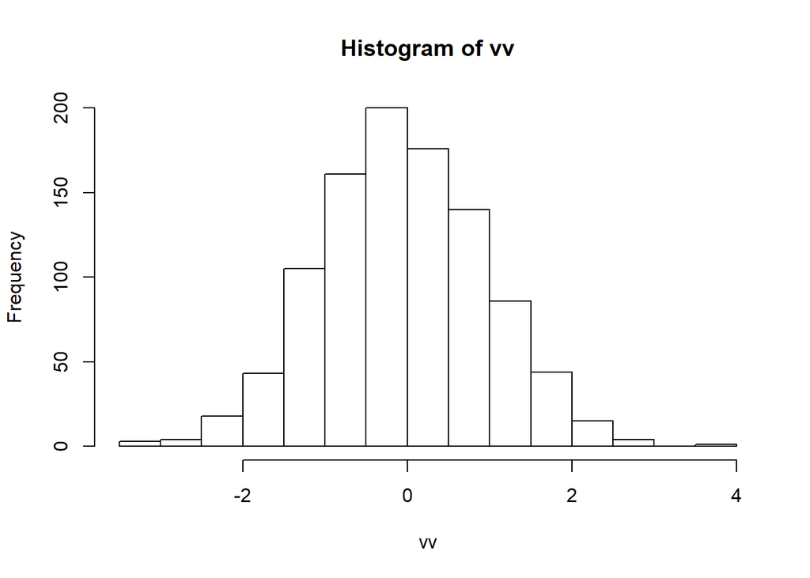

```r
hist(vv)    # Graphical summary
```

#### Other Ways to Create Vectors in R

Create a sequence with a fixed increment, `seq(from=..., to=..., by=..., length.out=...)`.

```r
seq(1,10,by=1)
```

```
##  [1]  1  2  3  4  5  6  7  8  9 10
```

```r
seq(1,10,length.out=10)
```

```
##  [1]  1  2  3  4  5  6  7  8  9 10
```

```r
1:10  # With an increment of 1
```

```
##  [1]  1  2  3  4  5  6  7  8  9 10
```

```r
seq(1,10,length.out=9)
```

```
## [1]  1.000  2.125  3.250  4.375  5.500  6.625  7.750  8.875 10.000
```

Create a vector containing elements with the same value `rep(x, times=..., each=...)`.

```r
rep(2,10)
```

```
##  [1] 2 2 2 2 2 2 2 2 2 2
```

```r
rep(1:4, times=2)
```

```
## [1] 1 2 3 4 1 2 3 4
```

```r
rep(1:4, each=2)
```

```
## [1] 1 1 2 2 3 3 4 4
```

#### Missing Values in R

In R, missing values are represented by “NA” (meaning Not Available). Any arithmetic operation that involves NA generates an NA.

```r
y <- c(1, NA, 3, 0, NA)
mean(y)
```

```
## [1] NA
```

```r
mean(y, na.rm=T)
```

```
## [1] 1.333333
```

```r
is.na(y)
```

```
## [1] FALSE  TRUE FALSE FALSE  TRUE
```

#### Comments in R

Anything that follows a `#` on the command line is taken as comment and ignored by R.

```r
a=1
b=2
#a=3
d=a+b
d
```

```
## [1] 3
```

### Matrices

To create a matrix, we use `matrix(data = NA, nrow = 1, ncol = 1, byrow = FALSE, dimnames = NULL)`

```r
M <- matrix(1:12,nrow=3,ncol=4,byrow=T)
M
```

```
##      [,1] [,2] [,3] [,4]
## [1,]    1    2    3    4
## [2,]    5    6    7    8
## [3,]    9   10   11   12
```

```r
M <- matrix(1:12,nrow=3,ncol=4)
```

#### Subsetting

Retrieve the elements of `M`.

```r
M[2,3]
```

```
## [1] 8
```

```r
M[2,]
```

```
## [1]  2  5  8 11
```

```r
M[,3]
```

```
## [1] 7 8 9
```

#### Column and Row Operations

To obtain the means for each column of the matrix `M`, we use `apply(X, MARGIN, FUN, ...)`

`X`: an array, including a matrix.

`MARGIN`: a vector giving the subscripts which the function will be applied over. E.g., for a matrix, 1 indicates rows, 2 indicates columns.

`FUN`: the function to be applied

```r
apply(M,2,mean)
```

```
## [1]  2  5  8 11
```

```r
apply(M,1,mean)
```

```
## [1] 5.5 6.5 7.5
```

```r
apply(M,2,sum)
```

```
## [1]  6 15 24 33
```

```r
apply(M,1,sum)
```

```
## [1] 22 26 30
```

#### Other operations on Matrices

Try the following commands and figure out their functionality.

```r
dim(M) # dimension
```

```
## [1] 3 4
```

```r
t(M) # transpose
```

```
##      [,1] [,2] [,3]
## [1,]    1    2    3
## [2,]    4    5    6
## [3,]    7    8    9
## [4,]   10   11   12
```

```r
sum(M) # summation
```

```
## [1] 78
```

```r
as.vector(M) # vectorize
```

```
##  [1]  1  2  3  4  5  6  7  8  9 10 11 12
```

### Data Frames

Data frames are fundamental to the use of the R modeling and graphics functions. A data frame is a generalization of a matrix, in which **different columns may have different modes**. All elements of any column must however have the **same mode**, i.e. all numeric or all factor, or all character.

The data set `clinic` consists of two variables, `type` and `score`. `type` refers to what patients take. `score` is a kind of health score of patients.

[output not shown]

Step 1. Input the data set. Label `type` and `score` as drug or placebo and health score respectively.

```r
type <- c(rep("drug",2),"placebo",rep("drug",2),rep("placebo",3))
score <- c(8,10,5,9,9,7,6,6)
clinic <- data.frame(type,score)
clinic
```

```
##      type score
## 1    drug     8
## 2    drug    10
## 3 placebo     5
## 4    drug     9
## 5    drug     9
## 6 placebo     7
## 7 placebo     6
## 8 placebo     6
```

Step 2. Calculate the means of health score for patients taking drug and for patients taking placebo respectively.

```r
mean(score[type=="drug"])
```

```
## [1] 9
```

```r
mean(score[type=="placebo"])
```

```
## [1] 6
```

Select columns or rows

```r
clinic[,2]
```

```
## [1]  8 10  5  9  9  7  6  6
```

```r
clinic[,"score"]
```

```
## [1]  8 10  5  9  9  7  6  6
```

```r
clinic[type=="drug",]
```

```
##   type score
## 1 drug     8
## 2 drug    10
## 4 drug     9
## 5 drug     9
```

logical operators

| Operator | Description |
| --- | --- |
| `<` | less than |
| `<=` | less than or equal to |
| `>` | greater than |
| `>=` | greater than or equal to |
| `==` | exactly equal to |
| `!=` | not equal to |
| `!x` | not x |
| `x\|y` | x or y |
| `x&y` | x and y |

### Lists

An R list is an object consisting of an ordered collection of objects known as its components. There is no particular need for the components to be of the same mode or type. For example, a list could consist of a numeric vector, a logical value, a matrix, a complex vector, a character array, a function, and so on.

Here is a simple example of how to make a list:

```r
lst <- list(name="Fred", wife="Mary", no.children=3, child.ages=c(4,7,9))
lst
```

```
## $name
## [1] "Fred"
##
## $wife
## [1] "Mary"
##
## $no.children
## [1] 3
##
## $child.ages
## [1] 4 7 9
```

```r
length(lst)
```

```
## [1] 4
```

```r
lst$child.ages
```

```
## [1] 4 7 9
```

```r
lst$child.ages[2]
```

```
## [1] 7
```

```r
class(lst$child.ages)
```

```
## [1] "numeric"
```

```r
class(lst$child.ages[2])
```

```
## [1] "numeric"
```

### Functions

Syntax: `ff<-function(x) {xxx; return(y)}`

A function is created using an assignment. On the right hand side, the parameters appear within round brackets. You can, if you wish, give a default. Following the closing “)” the function body appears. Except where the function body consists of just one statement, this is enclosed between curly braces `{ }`. The return value usually appears on the final line of the function body. It is recommended to explicitly write a “return” function.

Define a function that calculate the mean and standard deviation of a sample

```r
mean.and.sd <- function(x){
 av <- mean(x)
 sd <- sqrt(var(x))
 return(c(mean=av, SD=sd))
 }
x1<-rnorm(100)
mean.and.sd(x1)
```

```
##       mean         SD
## 0.07342937 1.13515776
```

```r
x2<-rnorm(10000)
mean.and.sd(x2)
```

```
##        mean          SD
## 0.004624308 1.017048717
```

### Controls Statements

The R has available a conditional construction of the form `if (expr_1) expr_2 else expr_3` where `expr_1` must evaluate to a single logical value.

Example:

```r
x <- rnorm(10)
if(sum(x)>0)
{
    print("Positive")
}  else  {
    print("negative")
}
```

```
## [1] "negative"
```

Another frequently used control statement is `for` loop:

```r
for(i in 1:10)
{
  print(i)
}
```

```
## [1] 1
## [1] 2
## [1] 3
## [1] 4
## [1] 5
## [1] 6
## [1] 7
## [1] 8
## [1] 9
## [1] 10
```

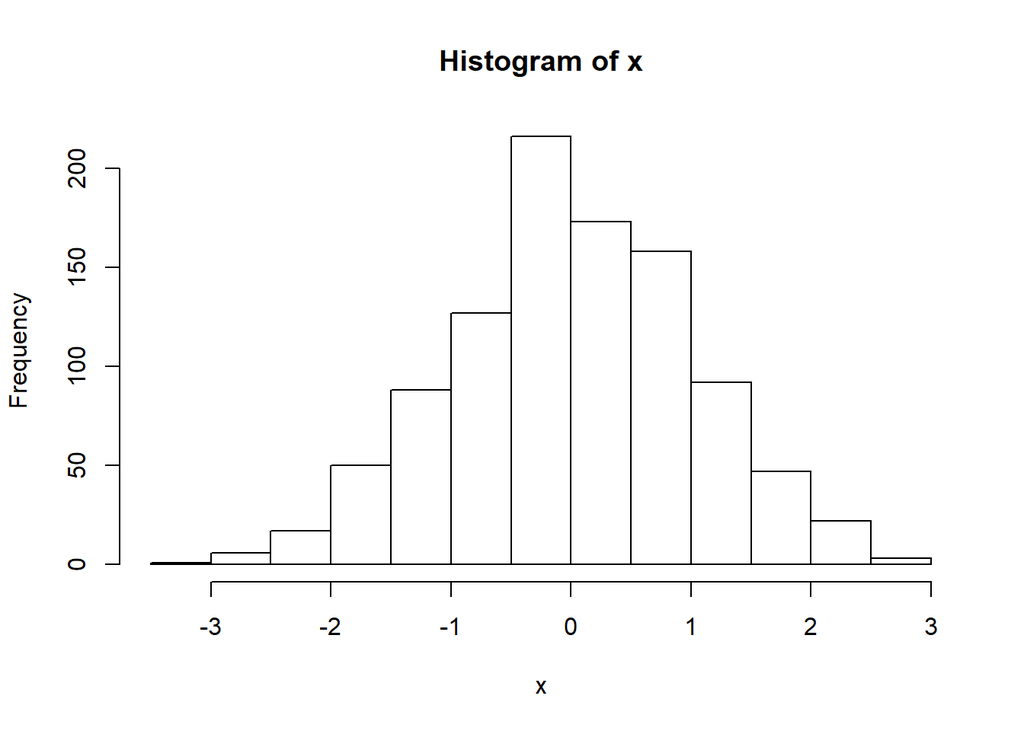

```r
x <- rnorm(1000)
x.pos <- rep(NA, length(x))
for(j in 1:length(x))
{
  if(x[j]<0)
  {
    x.pos[j]<-0
  } else {
    x.pos[j]<-x[j]
  }
}
hist(x)
```

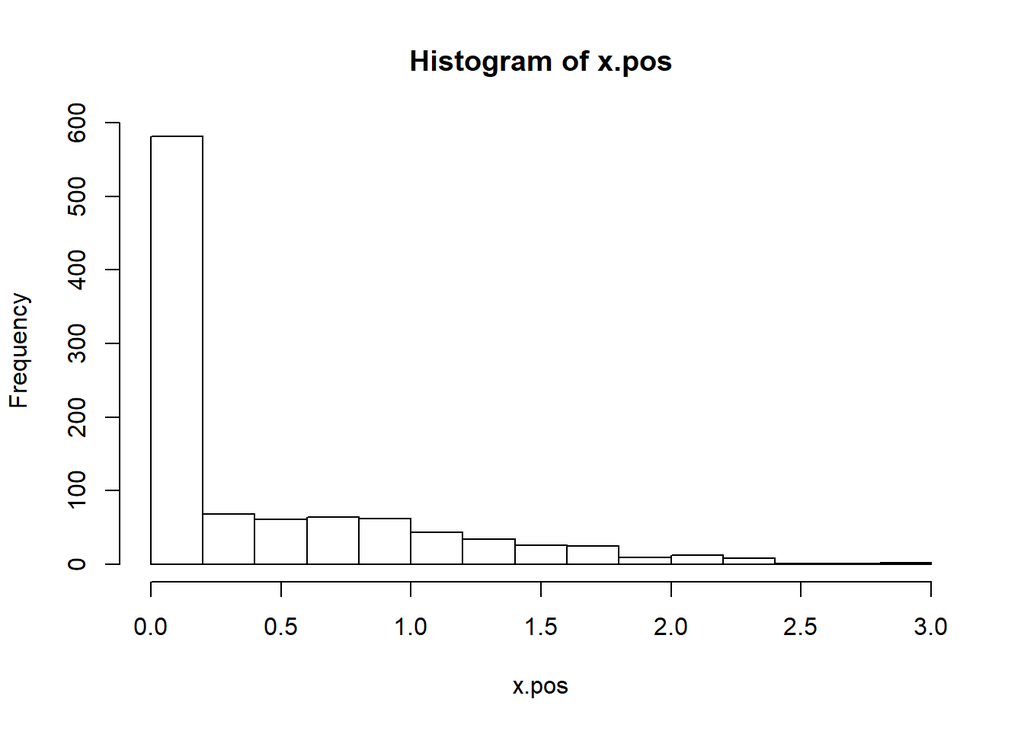

```r
hist(x.pos)
```

### Histograms

To plot a histogram, we use

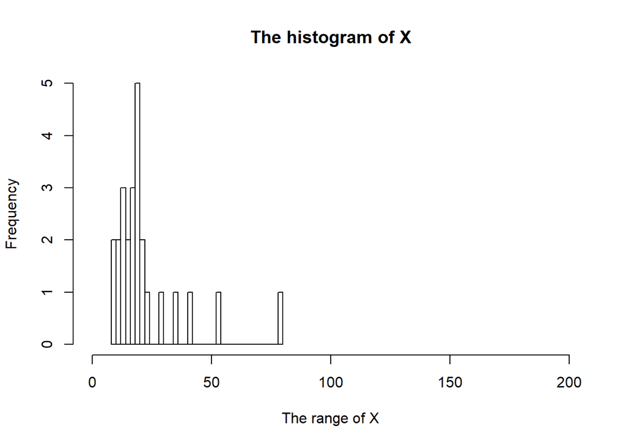

```r
delivery <- read.csv("data_delivery.csv",h=T)
hist(delivery$DeliveryTime, xlim=c(0,200), breaks=30, xlab="The range of X", main="The histogram of X")
```

In the code above, `breaks=` specifices the number of bins, `xlim=c(a,b)` or `ylim=c(a,b)` specify the range of x or y axis to [a,b], `xlab="ZZZ"` or `ylab="ZZZ"` specify the label attached to the x or y axis as ZZZ, `main="ZZZ"` specify the title attached to the plot as ZZZ.

### Scatter Plots

We first create a dataset by simulating 200 observations from the following linear model $y = \beta_0 + \beta_1 * x + \epsilon$ where $\beta_0=1$, $\beta_1=2$, $x ~ N(1, 4)$, $\epsilon ~ N(0,1)$. Then we visualize the data in a scatter plot.

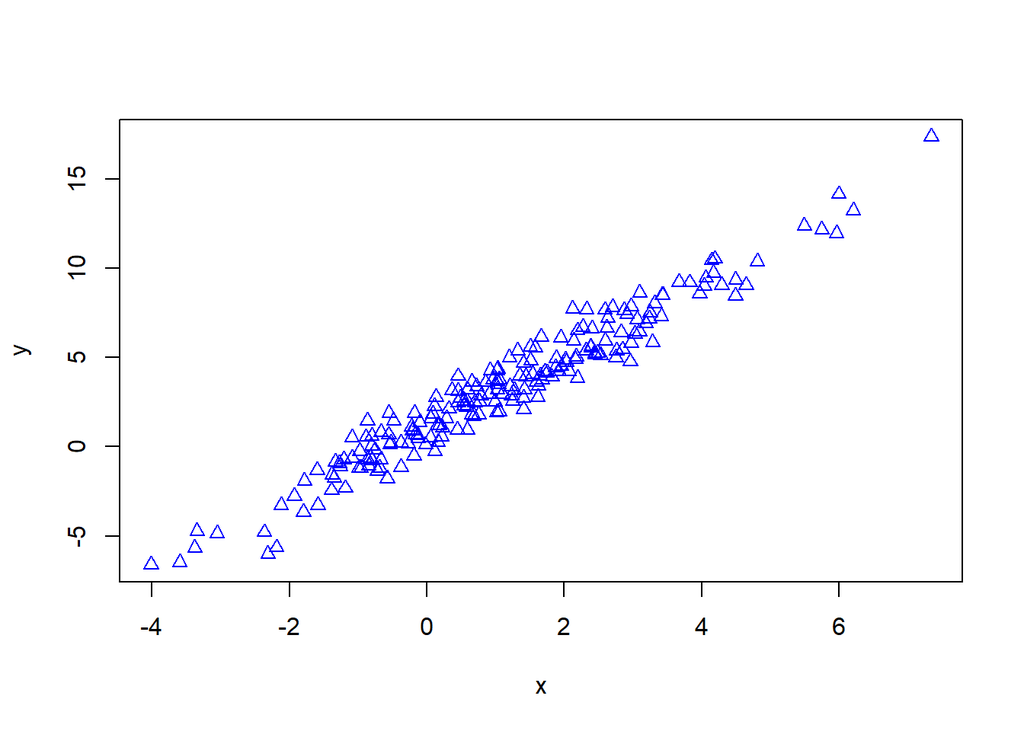

```r
x <- rnorm(200,mean=1,sd=2)
noise <- rnorm(200)
y <- 1+2*x+noise
plot(x,y,pch=2,col="blue")
```

In the code above, `pch=` specifies the type of symbol for each data point, `col="red"` specifies the color of the dots.

We can also plot multiple figures at one once to save space.

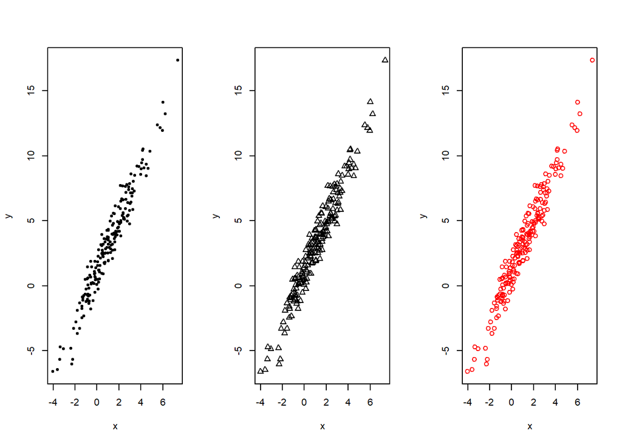

```r
par(mfrow=c(1,3))
plot(x,y,pch=20)
plot(x,y,pch=2)
plot(x,y,col="red")
```

Other features in plottings.

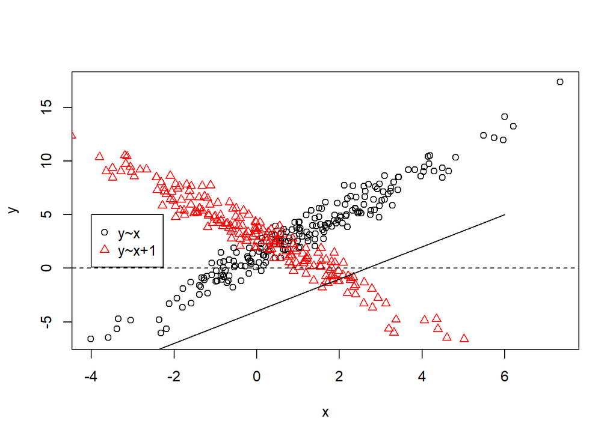

```r
plot(x,y)
points(-x+1, y, pch=2,col="red")
abline(h=0,lty=2)
lines(x=c(-4,6),y=c(-10,5))
legend(-4,5,legend=c("y~x","y~x+1"),pch=c(1,2),col=c("black","red"))
```

Tips and tricks: The function `points(...)` adds points to an existing plot. The functions `abline(...)` and `lines()` adds lines to an existing plot The function `legend(...)` attach a legend to an existing plot.

### Linear Regression in R

We use `lm(response ~ var1+var2+...+vark, data=...)` to perform linear regression analysis.

Note: `lm()` stands for linear model.

```r
model = lm(y~x)
summary(model)
```

```
##
## Call:
## lm(formula = y ~ x)
##
## Residuals:
##      Min       1Q   Median       3Q      Max
## -2.50590 -0.67319 -0.06679  0.62364  2.40528
##
## Coefficients:
##             Estimate Std. Error t value Pr(>|t|)
## (Intercept)  1.09091    0.07580   14.39   <2e-16 ***
## x            1.98932    0.03367   59.09   <2e-16 ***
## ---
## Signif. codes:  0 '***' 0.001 '**' 0.01 '*' 0.05 '.' 0.1 ' ' 1
##
## Residual standard error: 0.9347 on 198 degrees of freedom
## Multiple R-squared:  0.9463, Adjusted R-squared:  0.9461
## F-statistic:  3492 on 1 and 198 DF,  p-value: < 2.2e-16
```

```r
model$coef
```

```
## (Intercept)           x
##    1.090906    1.989316
```

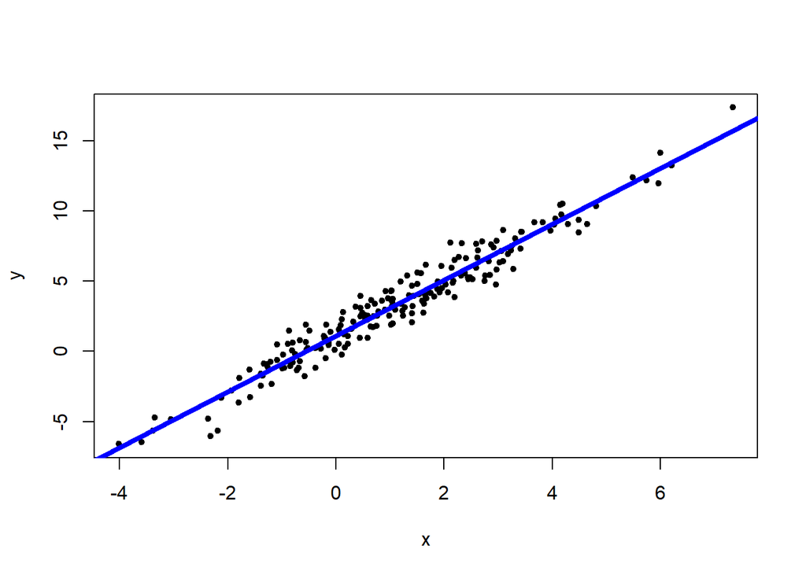

```r
plot(x,y,pch=20)
abline(a=model$coef[1], b=model$coef[2], lwd=4, col="blue")
```

### Exercises

#### Excercie 1

For the object `x_join`

- Delete the 2nd and 4th elements.
- Count how many 0 in `x_join`.

```r
x_join
x_join[-c(2,4)]
sum(x_join==0)
length(which(x_join==0))
```

#### Excercie 2

Use two R functions `sum()` and `length()` to calculate the variance of samples in the R object `x_join`.

Check if your result is the same as `var(x_join)`.

```r
sum((x_join-sum(x_join)/length(x_join))^2)/(length(x_join)-1)
var(x_join)
```

#### Excercie 3

Divide the vector `vv` into two vectors:

- `vv1` contains those with positive values
- `vv2` contains those with non-positive values

Summary the vector vv1.

```r
vv1 <- vv[vv>0]
length(vv1)
summary(vv1)
hist(vv1)
```

#### Excercie 4

Use the least lines of commands to generate the following matrix

```
##      celsius fahrenheit
## [1,]      25       77.0
## [2,]      26       78.8
## [3,]      27       80.6
## [4,]      28       82.4
## [5,]      29       84.2
## [6,]      30       86.0
```

```r
uu<-matrix(NA,nrow=6,ncol=2)
uu[,1]<-25:30
uu[,2]<-9/5*uu[,1]+32
colnames(uu)<-c("celsius","fahrenheit")

celsius <- 25:30
fahrenheit <- 9/5*celsius+32
cbind(celsius, fahrenheit)
```

#### Excercie 5

Suppose `M` is a matrix. You are asked to write your own function to realize the same functionality of the following command: `apply(M,2,mean)`. Note: You are only allowed to use one existing R function `dim()`. Do not call other functions.

```r
col.means<-function(M){ # Input: a matrix; Output: Column-wise means
    if(class(M)=="matrix"){
       n.row<-dim(M)[1]; n.col<-dim(M)[2]
       means<-rep(NA,n.col)
       for(i in 1:n.col){
          summation<-0
          for(j in 1:n.row) summation<-summation+M[j,i]
          means[i]<-summation/n.row
       }
       return(means)
    } else print("The input is not a matrix!")
}
M<-matrix(1:12,nrow=3)
col.means(M)
```

```
## [1]  2  5  8 11
```

```r
apply(M,2,mean)
```

```
## [1]  2  5  8 11
```

```r
col.means(2)
```

```
## [1] "The input is not a matrix!"
```

#### Excercie 6

Create a data set `student` in R as follows

```
##   ID  name sex math music
## 1 02  Mark   M   78    98
## 2 12  Bill   M   89    NA
## 3 23 Cathy   F   93    79
```

Create a data set `stu.bio` without any score, using the data set you created in Step 1.

Create a data set `student.m` by selecting observations with male students in the data set `student`.

Create a new variable GOOD in such a way that if the math score of a student is greater or equal to 90, put YES and otherwise put NO. Append the new variable to the data set `student`.

```r
ID<-c("02","12","23")
name<-c("Mark","Bill","Cathy")
sex<-c("M","M","F")
math<-c(78,89,93)
music<-c(98,NA,79)
student<-data.frame(ID,name,sex,math,music)
stu.bio<-student[,1:3]
student.m<-student[sex=="M",]
GOOD<-rep("YES",length(math))
GOOD[math<90]<-"NO"
student<-data.frame(student,GOOD)
```